# Project: Train a Quadcopter How to Fly

Design an agent to fly a quadcopter, and then train it using a reinforcement learning algorithm of your choice!

Try to apply the techniques you have learnt, but also feel free to come up with innovative ideas and test them.

## Instructions

Take a look at the files in the directory to better understand the structure of the project.

- `task.py`: Define your task (environment) in this file.
- `agents/`: Folder containing reinforcement learning agents.
  - `policy_search.py`: A sample agent has been provided here.
  - `agent.py`: Develop your agent here.
- `physics_sim.py`: This file contains the simulator for the quadcopter. **DO NOT MODIFY THIS FILE**.

For this project, you will define your own task in `task.py`. Although we have provided a example task to get you started, you are encouraged to change it. Later in this notebook, you will learn more about how to amend this file.

You will also design a reinforcement learning agent in `agent.py` to complete your chosen task.

You are welcome to create any additional files to help you to organize your code. For instance, you may find it useful to define a `model.py` file defining any needed neural network architectures.

## Controlling the Quadcopter

We provide a sample agent in the code cell below to show you how to use the sim to control the quadcopter. This agent is even simpler than the sample agent that you'll examine (in `agents/policy_search.py`) later in this notebook!

The agent controls the quadcopter by setting the revolutions per second on each of its four rotors. The provided agent in the `Basic_Agent` class below always selects a random action for each of the four rotors. These four speeds are returned by the `act` method as a list of four floating-point numbers.

For this project, the agent that you will implement in `agents/agent.py` will have a far more intelligent method for selecting actions!

```python
import random

class Basic_Agent():
    def __init__(self, task):
        self.task = task

    def act(self):
        new_thrust = random.gauss(450., 25.)
        return [new_thrust + random.gauss(0., 1.) for x in range(4)]
```

Run the code cell below to have the agent select actions to control the quadcopter.

Feel free to change the provided values of `runtime`, `init_pose`, `init_velocities`, and `init_angle_velocities` below to change the starting conditions of the quadcopter.

The `labels` list below annotates statistics that are saved while running the simulation. All of this information is saved in a text file `data.txt` and stored in the dictionary `results`.

```python
%load_ext autoreload
%autoreload 2

import csv
import numpy as np
from task import Task

# Modify the values below to give the quadcopter a different starting position.
runtime = 5.                                     # time limit of the episode
init_pose = np.array([0., 0., 10., 0., 0., 0.])  # initial pose
init_velocities = np.array([0., 0., 0.])         # initial velocities
init_angle_velocities = np.array([0., 0., 0.])   # initial angle velocities
file_output = 'data.txt'                         # file name for saved results

# Setup
task = Task(init_pose, init_velocities, init_angle_velocities, runtime)
agent = Basic_Agent(task)
done = False
labels = ['time', 'x', 'y', 'z', 'phi', 'theta', 'psi', 'x_velocity',
          'y_velocity', 'z_velocity', 'phi_velocity', 'theta_velocity',
          'psi_velocity', 'rotor_speed1', 'rotor_speed2', 'rotor_speed3', 'rotor_speed4']
results = {x : [] for x in labels}

# Run the simulation, and save the results.
with open(file_output, 'w') as csvfile:
    writer = csv.writer(csvfile)
    writer.writerow(labels)
    while True:
        rotor_speeds = agent.act()
        _, _, done = task.step(rotor_speeds)
        to_write = [task.sim.time] + list(task.sim.pose) + list(task.sim.v) + list(task.sim.angular_v) + list(rotor_speeds)
        for ii in range(len(labels)):
            results[labels[ii]].append(to_write[ii])
        writer.writerow(to_write)
        if done:
            break
```

Run the code cell below to visualize how the position of the quadcopter evolved during the simulation.

```python
import matplotlib.pyplot as plt
%matplotlib inline

plt.plot(results['time'], results['x'], label='x')
plt.plot(results['time'], results['y'], label='y')
plt.plot(results['time'], results['z'], label='z')
plt.legend()
_ = plt.ylim()
```

[output not shown]

The next code cell visualizes the velocity of the quadcopter.

```python
plt.plot(results['time'], results['x_velocity'], label='x_hat')
plt.plot(results['time'], results['y_velocity'], label='y_hat')
plt.plot(results['time'], results['z_velocity'], label='z_hat')
plt.legend()
_ = plt.ylim()
```

[output not shown]

Next, you can plot the Euler angles (the rotation of the quadcopter over the $x$-, $y$-, and $z$-axes),

```python
plt.plot(results['time'], results['phi'], label='phi')
plt.plot(results['time'], results['theta'], label='theta')
plt.plot(results['time'], results['psi'], label='psi')
plt.legend()
_ = plt.ylim()
```

[output not shown]

before plotting the velocities (in radians per second) corresponding to each of the Euler angles.

```python
plt.plot(results['time'], results['phi_velocity'], label='phi_velocity')
plt.plot(results['time'], results['theta_velocity'], label='theta_velocity')
plt.plot(results['time'], results['psi_velocity'], label='psi_velocity')
plt.legend()
_ = plt.ylim()
```

[output not shown]

Finally, you can use the code cell below to print the agent's choice of actions.

```python
plt.plot(results['time'], results['rotor_speed1'], label='Rotor 1 revolutions / second')
plt.plot(results['time'], results['rotor_speed2'], label='Rotor 2 revolutions / second')
plt.plot(results['time'], results['rotor_speed3'], label='Rotor 3 revolutions / second')
plt.plot(results['time'], results['rotor_speed4'], label='Rotor 4 revolutions / second')
plt.legend()
_ = plt.ylim()
```

[output not shown]

When specifying a task, you will derive the environment state from the simulator. Run the code cell below to print the values of the following variables at the end of the simulation:

- `task.sim.pose` (the position of the quadcopter in ($x,y,z$) dimensions and the Euler angles),
- `task.sim.v` (the velocity of the quadcopter in ($x,y,z$) dimensions), and
- `task.sim.angular_v` (radians/second for each of the three Euler angles).

```python
# the pose, velocity, and angular velocity of the quadcopter at the end of the episode
print(task.sim.pose)
print(task.sim.v)
print(task.sim.angular_v)
```

[output not shown]

In the sample task in `task.py`, we use the 6-dimensional pose of the quadcopter to construct the state of the environment at each timestep. However, when amending the task for your purposes, you are welcome to expand the size of the state vector by including the velocity information. You can use any combination of the pose, velocity, and angular velocity - feel free to tinker here, and construct the state to suit your task.

## The Task

A sample task has been provided for you in `task.py`. Open this file in a new window now.

The `__init__()` method is used to initialize several variables that are needed to specify the task.

- The simulator is initialized as an instance of the `PhysicsSim` class (from `physics_sim.py`).
- Inspired by the methodology in the original DDPG paper, we make use of action repeats. For each timestep of the agent, we step the simulation `action_repeats` timesteps. If you are not familiar with action repeats, please read the **Results** section in [the DDPG paper](https://arxiv.org/abs/1509.02971).
- We set the number of elements in the state vector. For the sample task, we only work with the 6-dimensional pose information. To set the size of the state (`state_size`), we must take action repeats into account.
- The environment will always have a 4-dimensional action space, with one entry for each rotor (`action_size=4`). You can set the minimum (`action_low`) and maximum (`action_high`) values of each entry here.
- The sample task in this provided file is for the agent to reach a target position. We specify that target position as a variable.

The `reset()` method resets the simulator. The agent should call this method every time the episode ends. You can see an example of this in the code cell below.

The `step()` method is perhaps the most important. It accepts the agent's choice of action `rotor_speeds`, which is used to prepare the next state to pass on to the agent. Then, the reward is computed from `get_reward()`. The episode is considered done if the time limit has been exceeded, or the quadcopter has travelled outside of the bounds of the simulation.

In the next section, you will learn how to test the performance of an agent on this task.

## The Agent

The sample agent given in `agents/policy_search.py` uses a very simplistic linear policy to directly compute the action vector as a dot product of the state vector and a matrix of weights. Then, it randomly perturbs the parameters by adding some Gaussian noise, to produce a different policy. Based on the average reward obtained in each episode (`score`), it keeps track of the best set of parameters found so far, how the score is changing, and accordingly tweaks a scaling factor to widen or tighten the noise.

Run the code cell below to see how the agent performs on the sample task.

```python
import sys
import pandas as pd
from agents.policy_search import PolicySearch_Agent
from task import Task

num_episodes = 1000
target_pos = np.array([0., 0., 10.])
task = Task(target_pos=target_pos)
agent = PolicySearch_Agent(task)

for i_episode in range(1, num_episodes+1):
    state = agent.reset_episode() # start a new episode
    while True:
        action = agent.act(state)
        next_state, reward, done = task.step(action)
        agent.step(reward, done)
        state = next_state
        if done:
            print("\rEpisode = {:4d}, score = {:7.3f} (best = {:7.3f}), noise_scale = {}".format(
                i_episode, agent.score, agent.best_score, agent.noise_scale), end="")  # [debug]
            break
    sys.stdout.flush()
```

[output not shown]

This agent should perform very poorly on this task. And that's where you come in!

## Define the Task, Design the Agent, and Train Your Agent!

Amend `task.py` to specify a task of your choosing. If you're unsure what kind of task to specify, you may like to teach your quadcopter to takeoff, hover in place, land softly, or reach a target pose.

After specifying your task, use the sample agent in `agents/policy_search.py` as a template to define your own agent in `agents/agent.py`. You can borrow whatever you need from the sample agent, including ideas on how you might modularize your code (using helper methods like `act()`, `learn()`, `reset_episode()`, etc.).

Note that it is **highly unlikely** that the first agent and task that you specify will learn well. You will likely have to tweak various hyperparameters and the reward function for your task until you arrive at reasonably good behavior.

As you develop your agent, it's important to keep an eye on how it's performing. Use the code above as inspiration to build in a mechanism to log/save the total rewards obtained in each episode to file. If the episode rewards are gradually increasing, this is an indication that your agent is learning.

```python
## TODO: Train your agent here.
import tensorflow as tf
gpu_options = tf.GPUOptions(per_process_gpu_memory_fraction=0.7)
sess = tf.Session(config=tf.ConfigProto(gpu_options=gpu_options))


import sys
#sys.path.insert(0, '/home/os/Desktop/udacityML/Reinforcment_learning/Proj_TeachQuad/RL-Quadcopter-2/agents')

#from agents import agent


import sys
import pandas as pd
#from agent import DDPG
#from task import Task          #takeoff task
from tasks.hover import Hover  #hover task
from tasks.takeoff import Takeoff  #hover task

import sys, shutil, csv
import numpy as np
from agents.agent import Actor, Critic, DDPG, GridObj
#from task import Task


num_episodes = 500
runtime = 10.
init_target_pos = np.random.rand()*10
# time limit of the episode
init_pose = np.array([0.0, 0.0, 0.0, 0.0, 0.0, 0.0])       # initial pose (x,y,z,phi,theta,psi);
#dt = 1.0/50.0  #from sim file
init_velocities = np.array([0.0, 0.0, 0.0])                # initial velocities
init_angle_velocities = np.array([0.0, 0.0, 0.0])          # initial angle velocities
current_sim_filename = "current_sim.txt"                   # file name for saved results
best_sim_filename = "best_sim.txt"                         # file name for saved results
target_pos = np.array([0., 0., 100])                                       #target position, which is [z]; ie: lift o
position_noise = 1
#task = Hover(init_pose=init_pose, init_velocities=init_velocities,init_angle_velocities=init_angle_velocities, runtime=runtime, target_pos=target_pos)
task = Takeoff(init_pose=init_pose, init_velocities=init_velocities,init_angle_velocities=init_angle_velocities, runtime=runtime, target_pos=target_pos, position_noise=position_noise)

#task = Task(target_pos=target_pos)
##################### grid

#numLayers = [2,3,4,5, 6,7]
#densUnits=[[100,80,70,60,50],[500,450,400,350,300]] #,[900,800,700,600,500]
numLayers = [2,3]
densUnits=[[64,64,32],[128,96,64]] #,[400,450,400,350,300]] #,[900,800,700,600,500]

#densUnits=[[64,32,48,60,50],[400,300,300,350,250]] #,[900,800,700,600,500]
#print(np.random.choice(densUnits[0]))
dropout_rates=[0, 0.1, 0.2,0.3, 0.1, 0.3,0.1, 0.2,0.1, 0.2, 0.2, 0.2,0.1, 0.3, 0.2]
#dropout_rates=np.zeros(15)


#best_reward = dict()
#best_reward = []
countBests = 0
best_listOflists = []

#create empty 2d array of lists
all_simValuesResults = np.empty((len(numLayers),len(densUnits)), dtype=np.object_)
all_simValuesResults.fill([])
all_simValuesResults = np.frompyfunc(list,1,1)(all_simValuesResults)
#all_results[3][0].append('foo')
#all_results

all_rewardResults = np.empty((len(numLayers),len(densUnits)), dtype=np.object_)
all_rewardResults.fill([])
all_rewardResults = np.frompyfunc(list,1,1)(all_rewardResults)

bestReward = None
best_AvgReward = -np.inf

allAgents = np.empty((len(numLayers),len(densUnits)), dtype=np.object_)
allAgents.fill([])
allAgents = np.frompyfunc(list,1,1)(allAgents)

bestAgent = None
firstTime = True

#fig, ax = plt.subplots(nrows=10, ncols=1)
fig = plt.figure()



for i_n,n in enumerate(numLayers):
    for i_units,units in enumerate(densUnits):
        print("i_n:numlayers = {}:{}, i_units:units = {}:{}".format(i_n,n,i_units,units))
        rand_critic_units = []
        for fixed_u in range(n):
            rand_critic_units.append(np.random.choice(units)) # sample a fixed set for both local and target critic, local and target actor
        rand_actor_units = []
        for fixed_u in range(n):
            rand_actor_units.append(np.random.choice(units)) # sample a fixed set for both local and target critic, local and target actor

        #random masks to experiment with different networks sizes
        actorStateNNMask = [np.random.rand()>0.2 for x in range(n)]
        criticStateNNMask = [np.random.rand()>0.2 for x in range(n)]
        criticActionNNMask = [np.random.rand()>0.2 for x in range(n)]




        gObj = GridObj(n ,rand_actor_units,dropout_rates,  n ,rand_critic_units,dropout_rates,actorStateNNMask,criticStateNNMask,criticActionNNMask)
        agent = DDPG(task,gObj)
        allAgents[i_n][i_units].append(agent) #store all agents for later



        #rewards = []


        worst_score = 1000000
        best_score = -1000000.
        reward_log = "reward.txt"

        reward_labels = ['episode', 'reward']
        reward_results = {x : [] for x in reward_labels}


        ################################ from above
        done = False
        labels = ['time', 'x', 'y', 'z', 'phi', 'theta', 'psi', 'x_velocity',
                  'y_velocity', 'z_velocity', 'phi_velocity', 'theta_velocity',
                  'psi_velocity', 'rotor_speed1', 'rotor_speed2', 'rotor_speed3', 'rotor_speed4']

        # Run the simulation, and save the results.
        ########################
        for i_episode in range(1, num_episodes+1):
            state = agent.reset_episode() # start a new episode
            total_reward = 0
            results = {x : [] for x in labels}

            with open(current_sim_filename, 'w') as csvfile:
                writer = csv.writer(csvfile)
                writer.writerow(labels)
                while True:
                    #running the simulation
                    action = agent.act(state)
                    #action4 = action*4 #this multiplication is dangerous, it converted the 1x4 vector to 1x16 (IT IS NOT CONSTANT MATRIX MULTIPLICATION)
                    #print("action4",action4) # 4 rotor speeds

                    motor_speeds = action
                    next_state, reward, done = task.step(action)
                    agent.step(action, reward, next_state, done)
                    state = next_state
                    total_reward += reward

                    best_score = max(best_score , total_reward)
                    worst_score = min(worst_score , total_reward)
                    #print("task.sim.pose",task.sim.pose) # 4 rotor speeds
                    #saving the current simulation on file
                    to_write = [task.sim.time] + list(task.sim.pose) + list(task.sim.v) + list(task.sim.angular_v) + list(motor_speeds)
                    writer.writerow(to_write)

                    for ii in range(len(labels)):
                        results[labels[ii]].append(to_write[ii])
                    if done:



                         # random.randint(1,21)*5

                        #save and print current results
                        #reward_results.append(total_reward)
                        reward_results['episode'].append(i_episode)
                        reward_results['reward'].append(total_reward)

                        all_simValuesResults[i_n][i_units].append(results)
                        #best_listOflists.append((reward_results['episode'], reward_results['reward']))
                        #all_rewardResults[i_n][i_units].append(reward_results['reward'])
                        all_rewardResults[i_n][i_units].append(total_reward)

                        print("\rEpisode = {:4d},     total_reward = {:9.3f}     (best = {:9.3f})".format(
                            i_episode, total_reward, best_score), end="", flush=True)

                        break

        if firstTime:
            print(":::::::::_____ firstTime")
            firstTime = False
            best_AvgReward = np.mean(reward_results['reward'][-10:])
        print("np.mean(reward_results['reward'][-10:])=",np.mean(reward_results['reward'][-10:]))
        print("best_AvgReward=",best_AvgReward)
        #last_best_reward_val = best_reward
        if np.mean(reward_results['reward'][-10:])> best_AvgReward :
            #best_reward = total_reward
            print("::::::::::::::; new best")
            countBests +=1
            #key = str(n) +", "+str(rand_critic_units)+", "+str(rand_actor_units)
            #best_reward[key]=total_reward
            bestReward = (n,rand_critic_units,rand_actor_units,total_reward)
            best_AvgReward = np.mean(reward_results['reward'][-10:])
            shutil.copyfile(current_sim_filename, best_sim_filename)
            bestAgent = agent

        print("\n :: mean over last 30 episods = {}, max is at episode = {}".format(np.mean(reward_results['reward'][-10:]), np.argmax(reward_results['reward'])))
print("bestReward=",bestReward)
```

[output not shown]

[output cut: 219 more lines]

```
best_AvgReward= 4.7349761599456475

 :: mean over last 30 episods = -14.206876689967359, max is at episode = 316
i_n:numlayers = 1:3, i_units:units = 0:[64, 64, 32]
Episode =  500,     total_reward =  -134.971     (best =  4113.460)np.mean(reward_results['reward'][-10:])= 165.1226864124224
best_AvgReward= 4.7349761599456475
::::::::::::::; new best

 :: mean over last 30 episods = 165.1226864124224, max is at episode = 469
i_n:numlayers = 1:3, i_units:units = 1:[128, 96, 64]
Episode =  500,     total_reward =     2.918     (best =  4139.330)np.mean(reward_results['reward'][-10:])= -26.432920170749878
best_AvgReward= 165.1226864124224

 :: mean over last 30 episods = -26.432920170749878, max is at episode = 342
bestReward= (3, [64, 64, 64], [32, 64, 64], -134.97093739682086)
```

```python
from pylab import *
def smooth(x,window_len=11,window='hanning'):
    """smooth the data using a window with requested size.

    This method is based on the convolution of a scaled window with the signal.
    The signal is prepared by introducing reflected copies of the signal
    (with the window size) in both ends so that transient parts are minimized
    in the begining and end part of the output signal.

    input:
        x: the input signal
        window_len: the dimension of the smoothing window; should be an odd integer
        window: the type of window from 'flat', 'hanning', 'hamming', 'bartlett', 'blackman'
            flat window will produce a moving average smoothing.

    output:
        the smoothed signal

    example:

    t=linspace(-2,2,0.1)
    x=sin(t)+randn(len(t))*0.1
    y=smooth(x)

    see also:

    numpy.hanning, numpy.hamming, numpy.bartlett, numpy.blackman, numpy.convolve
    scipy.signal.lfilter

    TODO: the window parameter could be the window itself if an array instead of a string
    NOTE: length(output) != length(input), to correct this: return y[(window_len/2-1):-(window_len/2)] instead of just y.
    """

    if x.ndim != 1:
        raise ValueError("smooth only accepts 1 dimension arrays.")

    if x.size < window_len:
        raise ValueError("Input vector needs to be bigger than window size.")


    if window_len<3:
        return x


    if not window in ['flat', 'hanning', 'hamming', 'bartlett', 'blackman']:
        raise ValueError("Window is on of 'flat', 'hanning', 'hamming', 'bartlett', 'blackman'")


    s=np.r_[x[window_len-1:0:-1],x,x[-2:-window_len-1:-1]]
    #print(len(s))
    if window == 'flat': #moving average
        w=np.ones(window_len,'d')
    else:
        w=eval('np.'+window+'(window_len)')

    y=np.convolve(w/w.sum(),s,mode='valid')
    return y
```

## Plot the Rewards

Once you are satisfied with your performance, plot the episode rewards, either from a single run, or averaged over multiple runs.

```
No handles with labels found to put in legend.
```

```
[num layers n] = 2, [num units]= [64, 64, 32]
```

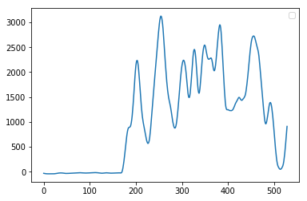

```
No handles with labels found to put in legend.
```

```
[num layers n] = 2, [num units]= [128, 96, 64]
```

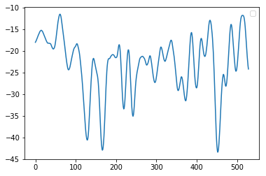

```
[num layers n] = 3, [num units]= [64, 64, 32]
```

```
No handles with labels found to put in legend.
```

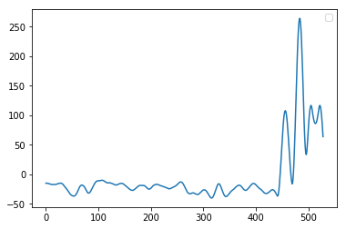

```
No handles with labels found to put in legend.
```

```
[num layers n] = 3, [num units]= [128, 96, 64]
```

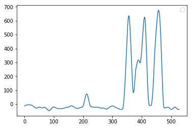

```
i_n:[num layers] = 0:2, i_units:[units]= 0:[64, 64, 32]
```

```
No handles with labels found to put in legend.
```

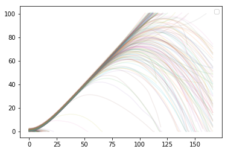

```
i_n:[num layers] = 0:2, i_units:[units]= 1:[128, 96, 64]
```

```
No handles with labels found to put in legend.
```

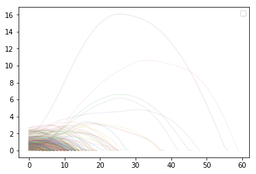

```
i_n:[num layers] = 1:3, i_units:[units]= 0:[64, 64, 32]
```

```
No handles with labels found to put in legend.
```

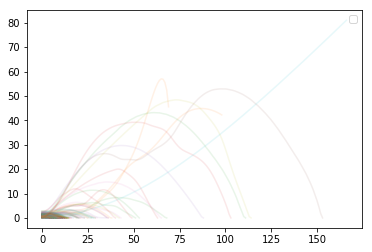

```
i_n:[num layers] = 1:3, i_units:[units]= 1:[128, 96, 64]
```

```
No handles with labels found to put in legend.
```

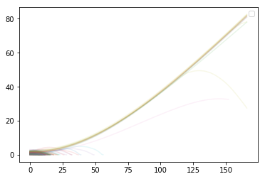

```python
## TODO: Plot the rewards.
import time
y_raw = []
# Plot the quadcopter height
for i_n,n in enumerate(numLayers):
    for i_units,units in enumerate(densUnits):
        print("[num layers n] = {}, [num units]= {} ".format(n,units))
        arr = np.array(all_rewardResults[i_n][i_units])
        #print(arr.shape)
        ySmooth = smooth(arr,30)
        plt.plot(ySmooth)
        plt.legend()
        _ = plt.ylim()
        plt.show()





# Plot the quadcopter height
for i_n,n in enumerate(numLayers):
    for i_units,units in enumerate(densUnits):
        print("i_n:[num layers] = {}:{}, i_units:[units]= {}:{} ".format(i_n,n,i_units,units))
        for episodeResult in all_simValuesResults[i_n][i_units]:
            plt.plot( episodeResult['z'], alpha=0.1) #print("r=",r['z'])

        plt.legend()
        _ = plt.ylim()
        plt.show()
```

```python
print("random parameters found for best agent:")

print("- bestAgent numb of layers=",bestAgent.actor_local.gridObj.actor_numLayers)

print("- bestAgent actor numb of units=",bestAgent.actor_local.gridObj.actor_layersUnitNum )
print("- bestAgent actor_dropout_rate=",bestAgent.actor_local.gridObj.actor_dropout_rate )

print("- bestAgent critic numb of units=",bestAgent.critic_local.gridObj.critic_layersUnitNum )
print("- bestAgent critic_dropout_rate=",bestAgent.critic_local.gridObj.critic_dropout_rate )
print("- bestAgent state pathway criticActionNNMask=",bestAgent.critic_local.gridObj.criticActionNNMask )
print("- bestAgent action pathway criticActionNNMask=",bestAgent.critic_local.gridObj.criticActionNNMask )

print("- bestAgent numb of units=",bestAgent.actor_local.gridObj)
```

```
random parameters found for best agent:
- bestAgent numb of layers= 3
- bestAgent actor numb of units= [32, 64, 64]
- bestAgent actor_dropout_rate= [0, 0.1, 0.2, 0.3, 0.1, 0.3, 0.1, 0.2, 0.1, 0.2, 0.2, 0.2, 0.1, 0.3, 0.2]
- bestAgent critic numb of units= [64, 64, 64]
- bestAgent critic_dropout_rate= [0, 0.1, 0.2, 0.3, 0.1, 0.3, 0.1, 0.2, 0.1, 0.2, 0.2, 0.2, 0.1, 0.3, 0.2]
- bestAgent state pathway criticActionNNMask= [True, True, False]
- bestAgent action pathway criticActionNNMask= [True, True, False]
- bestAgent numb of units= <agents.agent.GridObj object at 0x7fbac5cf05f8>
```

## Reflections

**Question 1**: Describe the task that you specified in `task.py`. How did you design the reward function?

**Answer**: I had used a final reward (sparse reward) of 1000 when the agent position exceed the target position. in the other hand, immediate rewards are handed to agent based on a factor multiplyed by the inverse of the position error. so the agent will learn immediatly if he is heading to the right way or not. I also credited the agent if he has any positive velocity or acceleration in the z-direction.

**Question 2**: Discuss your agent briefly, using the following questions as a guide:

- What learning algorithm(s) did you try? What worked best for you?
- What was your final choice of hyperparameters (such as $\alpha$, $\gamma$, $\epsilon$, etc.)?
- What neural network architecture did you use (if any)? Specify layers, sizes, activation functions, etc.

**Answer**: I used the suggested DDPG algorithm and it worked great. I did not modify the parameters supplied and I used a manuall grid search to explore different numbers of layers and sample randomly from different lists of units. at the end, many architectures could work but I used 3 Dense layers network with Leaky Relu activation and some dropouts to avoid overfitting with critic number of units [64, 64, 64] and action number of units [32, 64, 64]

**Question 3**: Using the episode rewards plot, discuss how the agent learned over time.

- Was it an easy task to learn or hard?
- Was there a gradual learning curve, or an aha moment?
- How good was the final performance of the agent? (e.g. mean rewards over the last 10 episodes)

**Question 4**: Briefly summarize your experience working on this project. You can use the following prompts for ideas.

- What was the hardest part of the project? (e.g. getting started, plotting, specifying the task, etc.)
- Did you find anything interesting in how the quadcopter or your agent behaved?

**Answer**:

- adjusting the reward function and many different parameters at once
- yes, I noticed that sometimes just two motors were spinning all the time and the other 2 motors just got to the maximum thrust for a secund in order to reach the target. I was expecting all motor to be spining at the same rate